# Análisis Descriptivo - Línea Acceso

CoV-IMPACT- C** “Coronavirus Impact Monitor. Policy, Access, Control and Transectorial Consequences” Proyecto ANID-COVID N° 960

por Valentina Andrade

02 octubre, 2020

[figure not shown]

# 1 Descripción de la base de datos

El siguiente análisis está desarrollado en base a la encuesta panel “Monitoreo Nacional de Síntomas y Prácticas COVID-19” (MOVID-19). A la fecha, **MOVID-19** ha recopilado un total de 58266 y un total de 274 variables.

El presente informe tiene por objetivo mostrar estadísticos descriptivos de variables del **Módulo de Acceso** , especialmente de aquellas preguntas sobre acceso a prestaciones de salud no relacionadas al COVID-19.

Para su conocimiento, [las variables indicadas son](https://docs.google.com/spreadsheets/d/1NtZVYC_yTEswUgR2bQg3iq3AhJfukCadNh3g-WF3Bh8/edit#gid=0):

**Tabla 1.** Libro de códigos para análisis de Acceso No COVID-19 **A. Filtros y prestaciones de salud**

| Variable | Definición |
| --- | --- |
| nc1_problema | ¿Desde marzo de este año hasta hoy, ¿ha tenido un nuevo problema de salud o accidente no relacionado con COVID-19? |
| nc2_consulta | ¿Tuvo alguna consulta o atención médica por ese nuevo problema de salud o accidente? |
| nc3_posp_consulta | Consulta por problema de salud no COVID-19 (urgente o no urgente) |
| nc3_posp_vacuna | Vacunación obligatoria |
| nc3_posp_examen | Toma de exámenes de laboratorio, radiografías, Papanicolau (PAP), mamografías, ecografías o similares |
| nc3_posp_insumos | Retiro o compra de medicamentos y/o ayudas técnicas (lentes, audífonos) |
| nc3_posp_cirugia | Cirugías electivas o no urgentes |
| nc3_posp_otra | Otras atenciones de salud o consultas médicas |
| nc3_posp_null | Ninguna de las anteriores |
| nc3_posp_otra_TEXT | Texto de Otra |

**B. Razones de no consulta**

| Variable | Definición |
| --- | --- |
| nc4_pq_nimporta | Porque no le pareció importante controlarse |
| nc4_pq_costo | Por el costo económico |
| nc4_pq_nosabia | Porque no sabía dónde realizarlo |
| nc4_pq_tiempo | Porque tenía que esperar mucho tiempo |
| nc4_pq_empeorar | Porque está esperando a empeorar |
| nc4_pq_temor | Por miedo a contagiarse de COVID-19 |
| nc4_pq_leves | Porque tiene sintomas leves |
| nc4_pq_sistlleno | Porque el sistema de salud está muy lleno |
| nc4_pq_transporte | No contó con transporte para trasladarse al lugar de atención. |
| nc4_pq_cuidados | No tuvo con quien dejar a personas a su cuidado niños/as, personas mayores o personas en situación de dependencia). |
| nc4_pq_cancela | El consultorio, hospital o clínica le suspendió la hora y no le ha reagendado |
| nc4_pq_otra | Otra |
| nc4_pq_otra_TEXT | Texto de Otra |

**C. Acceso salud para Crónicos**

| Variable | Definición |
| --- | --- |
| Variable | Definición |
| crn1_consulta_reg | Usted indicó al registrarse en este estudio que tenía una o más condiciones o enfermedades crónicas. Desde marzo de este año, ¿ha asistido a alguna consulta o atención médica para controlar su/s enfer… |
| crn2_posponer_reg | ¿Desde marzo de este año, ha tenido que posponer alguno de sus controles de su enfermedad/es crónica/s? |
| crn3_pq_nimporta_reg | Porque no le pareció importante controlarse |
| crn3_pq_costo_reg | Por el costo económico |
| crn3_pq_nosabia_reg | Porque no sabía dónde realizarlo |
| crn3_pq_tiempo.1 | Porque tenía que esperar mucho tiempo |
| crn3_pq_temor_reg | Por miedo a contagiarse de COVID-19 |
| crn3_pq_sistlleno_reg | Porque el sistema de salud está muy lleno |
| crn3_pq_transporte_reg | No contó con transporte para trasladarse al lugar de atención. |
| crn3_pq_cuidados_reg | No tuvo con quien dejar a personas a su cuidado niños/as, personas mayores o personas en situación de dependencia). |
| crn3_pq_cancela_reg | El consultorio, hospital o clínica le suspendió la hora y no le ha reagendado |
| crn3_pq_otra_reg | Otra |
| crn3_pq_otra_reg_TEXT | Texto de Otra |

# 2 Personas que reportan un problema de salud no relacionado a COVID-19

En la encuesta MOVID-19 3942 participantes indicaron tener nuevos problemas de salud o accidente **no relacionado con COVID-19**. El siguiente bloque de preguntas se les aplica a todos los participantes de MOVID-19.

**Tabla 2**. Estadísticos descriptivos sociodemográficos de participantes MOVID-19

| No | Variable | Stats / Values | Freqs (% of Valid) | Graph | Valid | Missing |
| --- | --- | --- | --- | --- | --- | --- |
| 1 | sexo [character] | 1. Femenino 2. Masculino 3. Otro | 27467 (69.2%) 12184 (30.7%) 69 ( 0.2%) | IIIIIIIIIIIII IIIIII | 39720 (100%) | 1 (0%) |
| 2 | edad_cat [character] | 1. 18 a 30 2. 30 a 39 3. 40 a 49 4. 50 a 59 5. 60 a 69 6. 70 a 79 7. 80+ | 6347 (16.0%) 10795 (27.2%) 9493 (23.9%) 7135 (18.0%) 4415 (11.1%) 1388 ( 3.5%) 117 ( 0.3%) | III IIIII IIII III II | 39690 (99.92%) | 31 (0.08%) |
| 3 | educ_3cat [character] | 1. Media o menos 2. Profesional 3. Técnica | 2517 ( 7.1%) 28106 (79.0%) 4969 (14.0%) | I IIIIIIIIIIIIIII II | 35592 (89.6%) | 4129 (10.4%) |
| 4 | prev [character] | 1. FONASA 2. Fuerzas Armadas y de Orde 3. ISAPRE 4. Ninguna 5. Otra | 12030 (35.3%) 390 ( 1.1%) 20404 (59.9%) 896 ( 2.6%) 339 ( 1.0%) | IIIIIII IIIIIIIIIII | 34059 (85.75%) | 5662 (14.25%) |
| 5 | region [character] | 1. Metropolitana de Santiago 2. Valparaíso 3. Biobío 4. Libertador General Bernar 5. Los Lagos 6. La Araucanía 7. Maule 8. Coquimbo 9. Antofagasta 10. Los Ríos [ 6 others ] | 26443 (66.7%) 3681 ( 9.3%) 1496 ( 3.8%) 1138 ( 2.9%) 1126 ( 2.8%) 1021 ( 2.6%) 932 ( 2.4%) 891 ( 2.2%) 723 ( 1.8%) 538 ( 1.4%) 1667 ( 4.2%) | IIIIIIIIIIIII I | 39656 (99.84%) | 65 (0.16%) |

Fuente: Elaboración de MOVID-19 *Nota*: Solo fueron consideradas (i) la última observación de las personas con datos para (ii) en el módulo de acceso a prestaciones de salud no relacionadas a COVID-19

## 2.1 Acceso a salud

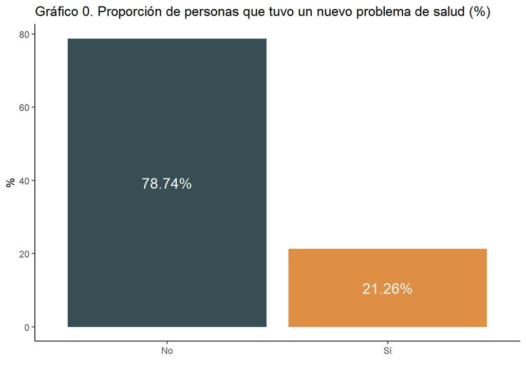

En el *Gráfico 1* se reporta la proporción de personas que tuvieron un nuevo problema de salud y si estas realizaron o no consulta médica.

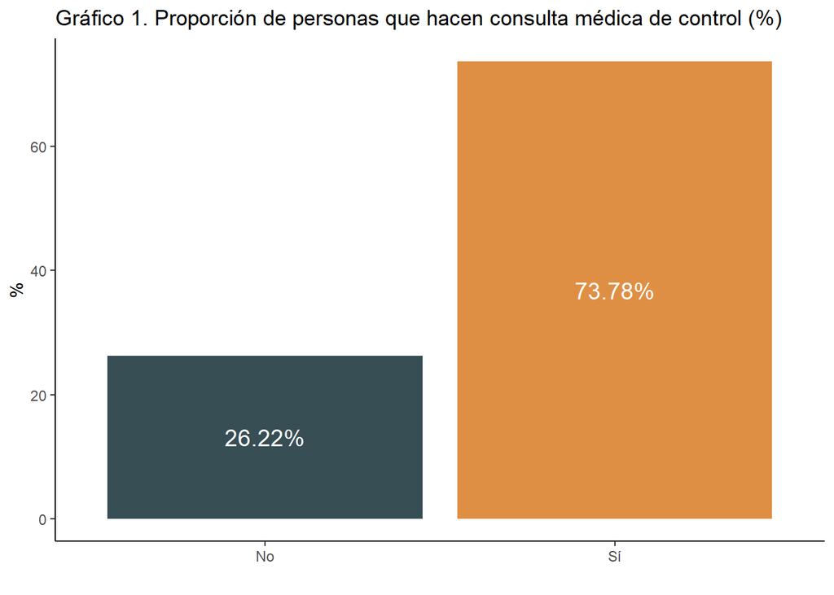

### 2.1.1 Composición sociodemográfica

En la *Tabla 3* se describe las características sociodemográficas de quienes reportan un problema de salud o accidente **no relacionado con COVID-19**, indicando la proporción de quiénes de ellos realizaron o no consultas médicas.

**Tabla 3.** Estadísticos descriptivos para quienes indican reportar un problema de salud

| Sociodemográfico Variable | Sociodemográfico Subgrupo | Acceso Consultó | Acceso n | Acceso % |
| --- | --- | --- | --- | --- |
| **Edad** |  |  |  |  |
| edad_3cat | 18 a 39 | No | 342 | 28.24 |
|  |  | Sí | 869 | 71.76 |
|  | 40 a 64 | No | 566 | 26.09 |
|  |  | Sí | 1603 | 73.91 |
|  | 65 y más | No | 121 | 22.20 |
|  |  | Sí | 424 | 77.80 |
| **Nivel Educacional** |  |  |  |  |
| educ_4cat | Basica o sin estudios | No | 4 | 36.36 |
|  |  | Sí | 7 | 63.64 |
|  | Media | No | 67 | 27.69 |
|  |  | Sí | 175 | 72.31 |
|  | Profesional | No | 830 | 25.82 |
|  |  | Sí | 2385 | 74.18 |
|  | Tecnica | No | 128 | 28.13 |
|  |  | Sí | 327 | 71.87 |
| **Región** |  |  |  |  |
| region | Antofagasta | No | 18 | 35.29 |
|  |  | Sí | 33 | 64.71 |
|  | Arica y Parinacota | No | 4 | 28.57 |
|  |  | Sí | 10 | 71.43 |
|  | Atacama | No | 5 | 38.46 |
|  |  | Sí | 8 | 61.54 |
|  | Aysén del General Carlos Ibáñez del Campo | No | 2 | 22.22 |
|  |  | Sí | 7 | 77.78 |
|  | Biobío | No | 51 | 30.18 |
|  |  | Sí | 118 | 69.82 |
|  | Coquimbo | No | 19 | 23.75 |
|  |  | Sí | 61 | 76.25 |
|  | La Araucanía | No | 21 | 28.00 |
|  |  | Sí | 54 | 72.00 |
|  | Libertador General Bernardo O’Higgins | No | 19 | 20.65 |
|  |  | Sí | 73 | 79.35 |
|  | Los Lagos | No | 20 | 19.23 |
|  |  | Sí | 84 | 80.77 |
|  | Los Ríos | No | 23 | 41.82 |
|  |  | Sí | 32 | 58.18 |
|  | Magallanes y de la Antártica Chilena | No | 5 | 17.24 |
|  |  | Sí | 24 | 82.76 |
|  | Maule | No | 23 | 29.11 |
|  |  | Sí | 56 | 70.89 |
|  | Metropolitana de Santiago | No | 690 | 25.46 |
|  |  | Sí | 2020 | 74.54 |
|  | Ñuble | No | 12 | 35.29 |
|  |  | Sí | 22 | 64.71 |
|  | Tarapacá | No | 9 | 36.00 |
|  |  | Sí | 16 | 64.00 |
|  | Valparaíso | No | 108 | 28.20 |
|  |  | Sí | 275 | 71.80 |
| **Sexo** |  |  |  |  |
| sexo | Femenino | No | 785 | 25.92 |
|  |  | Sí | 2243 | 74.08 |
|  | Masculino | No | 238 | 26.80 |
|  |  | Sí | 650 | 73.20 |
|  | Otro | No | 6 | 66.67 |
|  |  | Sí | 3 | 33.33 |

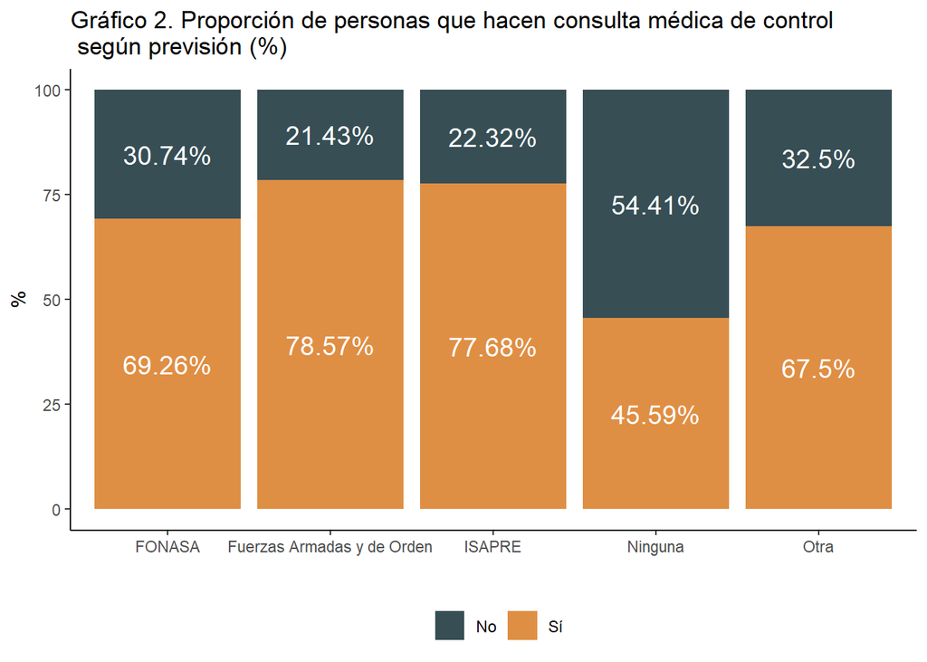

## 2.2 Acceso según división servicio salud

| Servicio de Salud | Consultó | n | % |
| --- | --- | --- | --- |
| Aconcagua | No | 13 | 41.94 |
|  | Sí | 18 | 58.06 |
| Antofagasta | No | 18 | 35.29 |
|  | Sí | 33 | 64.71 |
| Araucania Norte | No | 1 | 14.29 |
|  | Sí | 6 | 85.71 |
| Araucania Sur | No | 19 | 30.65 |
|  | Sí | 43 | 69.35 |
| Arauco | Sí | 1 | 100.00 |
| Arica | No | 4 | 28.57 |
|  | Sí | 10 | 71.43 |
| Atacama | No | 1 | 33.33 |
|  | Sí | 2 | 66.67 |
| Aysen | Sí | 2 | 100.00 |
| Biobio | No | 2 | 40.00 |
|  | Sí | 3 | 60.00 |
| Chiloe | No | 2 | 15.38 |
|  | Sí | 11 | 84.62 |
| Concepcion | No | 9 | 37.50 |
|  | Sí | 15 | 62.50 |
| Coquimbo | No | 18 | 23.08 |
|  | Sí | 60 | 76.92 |
| del Maule | No | 18 | 31.03 |
|  | Sí | 40 | 68.97 |
| del Reloncavi | No | 11 | 20.37 |
|  | Sí | 43 | 79.63 |
| Iquique | No | 9 | 36.00 |
|  | Sí | 16 | 64.00 |
| Magallanes | No | 5 | 17.24 |
|  | Sí | 24 | 82.76 |
| Metropolitano Central | No | 101 | 33.89 |
|  | Sí | 197 | 66.11 |
| Metropolitano Norte | No | 57 | 34.55 |
|  | Sí | 108 | 65.45 |
| Metropolitano Occidente | No | 36 | 26.87 |
|  | Sí | 98 | 73.13 |
| Metropolitano Oriente | No | 200 | 22.17 |
|  | Sí | 702 | 77.83 |
| Metropolitano Sur | No | 51 | 25.00 |
|  | Sí | 153 | 75.00 |
| Metropolitano Suroriente | No | 74 | 25.87 |
|  | Sí | 212 | 74.13 |
| Nuble | No | 1 | 20.00 |
|  | Sí | 4 | 80.00 |
| OHiggins | No | 15 | 20.55 |
|  | Sí | 58 | 79.45 |
| Osorno | No | 7 | 20.59 |
|  | Sí | 27 | 79.41 |
| Talcahuano | No | 7 | 38.89 |
|  | Sí | 11 | 61.11 |
| Valdivia | No | 22 | 41.51 |
|  | Sí | 31 | 58.49 |
| Valparaiso San Antonio | No | 14 | 32.56 |
|  | Sí | 29 | 67.44 |
| Vina del Mar Quillota | No | 13 | 23.64 |
|  | Sí | 42 | 76.36 |

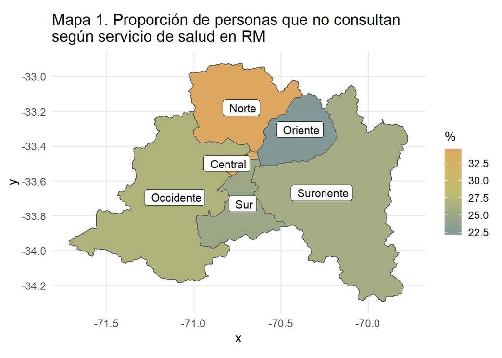

## 2.3 Tipo de prestaciones que se posponen

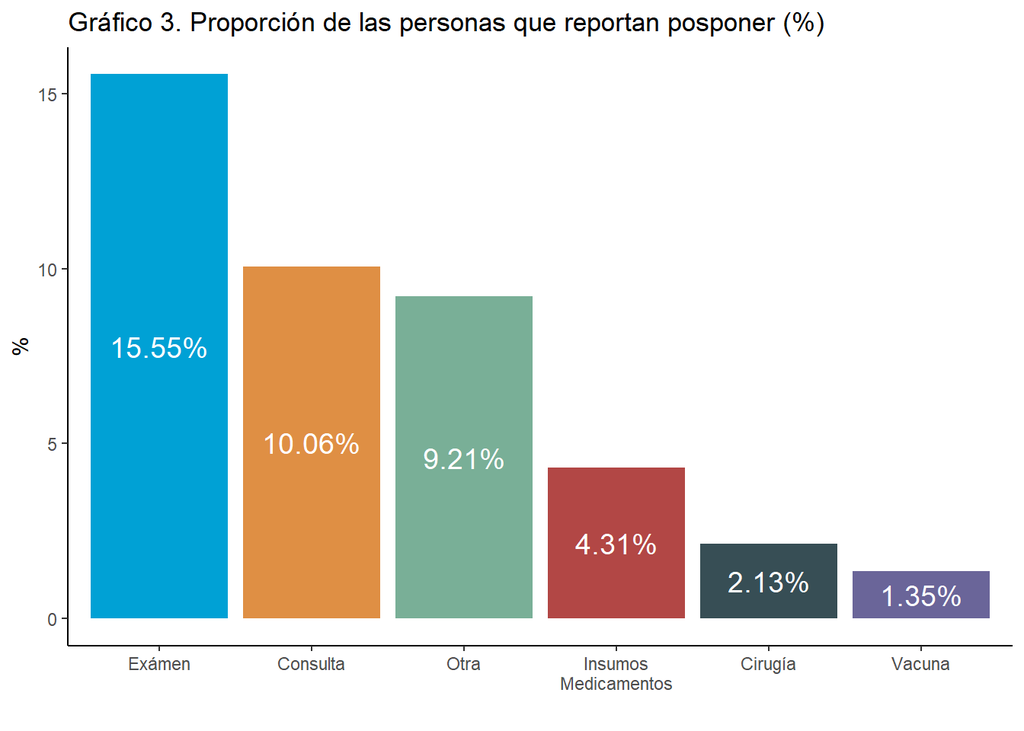

[figure not shown]

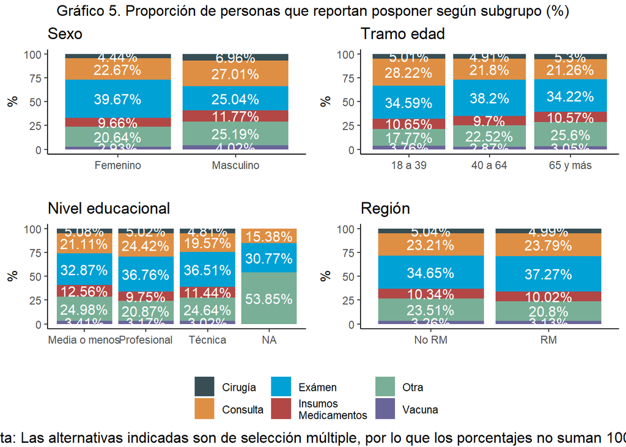

## 2.4 Razones para posponer prestaciones

**Tabla 4.** Proporción de personas que reporta cada razón para posponer

| Razón | n | % |
| --- | --- | --- |
| Cancela | 2547 | 16.16 |
| Costo | 939 | 5.96 |
| Cuidados | 608 | 3.86 |
| Empeorar | 965 | 6.12 |
| Síntomas leves | 1486 | 9.43 |
| No importa | 1510 | 9.58 |
| No sabía | 285 | 1.81 |
| Otra | 2689 | 17.06 |
| Sistema lleno | 2010 | 12.75 |
| Miedo al contagio | 9013 | 57.18 |
| Tiempo | 500 | 3.17 |
| Transporte | 375 | 2.38 |

# 3 Personas que reportan un problema de salud crónico

| No | Variable | Stats / Values | Freqs (% of Valid) | Graph | Valid | Missing |
| --- | --- | --- | --- | --- | --- | --- |
| 1 | sexo [character] | 1. Femenino 2. Masculino 3. Otro | 36430 (69.9%) 15598 (29.9%) 101 ( 0.2%) | IIIIIIIIIIIII IIIII | 52129 (100%) | 1 (0%) |
| 2 | edad_cat [character] | 1. 18 a 30 2. 30 a 39 3. 40 a 49 4. 50 a 59 5. 60 a 69 6. 70 a 79 7. 80+ | 7589 (14.6%) 13576 (26.1%) 12423 (23.8%) 9799 (18.8%) 6504 (12.5%) 2032 ( 3.9%) 160 ( 0.3%) | II IIIII IIII III II | 52083 (99.91%) | 47 (0.09%) |
| 3 | educ_3cat [character] | 1. Media o menos 2. Profesional 3. Técnica | 3151 ( 6.6%) 38394 (80.0%) 6444 (13.4%) | I IIIIIIIIIIIIIIII II | 47989 (92.06%) | 4141 (7.94%) |
| 4 | prev [character] | 1. FONASA 2. Fuerzas Armadas y de Orde 3. ISAPRE 4. Ninguna 5. Otra | 16088 (34.6%) 503 ( 1.1%) 28213 (60.7%) 1175 ( 2.5%) 477 ( 1.0%) | IIIIII IIIIIIIIIIII | 46456 (89.12%) | 5674 (10.88%) |
| 5 | region [character] | 1. Metropolitana de Santiago 2. Valparaíso 3. Biobío 4. Los Lagos 5. Libertador General Bernar 6. La Araucanía 7. Maule 8. Coquimbo 9. Antofagasta 10. Los Ríos [ 6 others ] | 35153 (67.5%) 4799 ( 9.2%) 1964 ( 3.8%) 1430 ( 2.7%) 1429 ( 2.7%) 1284 ( 2.5%) 1185 ( 2.3%) 1115 ( 2.1%) 899 ( 1.7%) 720 ( 1.4%) 2063 ( 4.0%) | IIIIIIIIIIIII I | 52041 (99.83%) | 89 (0.17%) |

Fuente: Elaboración de MOVID-19

## 3.1 Acceso a salud

En el *Gráfico 5* se reporta la proporción de personas que tienen problemas de salud crónicos y si estas realizaron o no consulta médica.

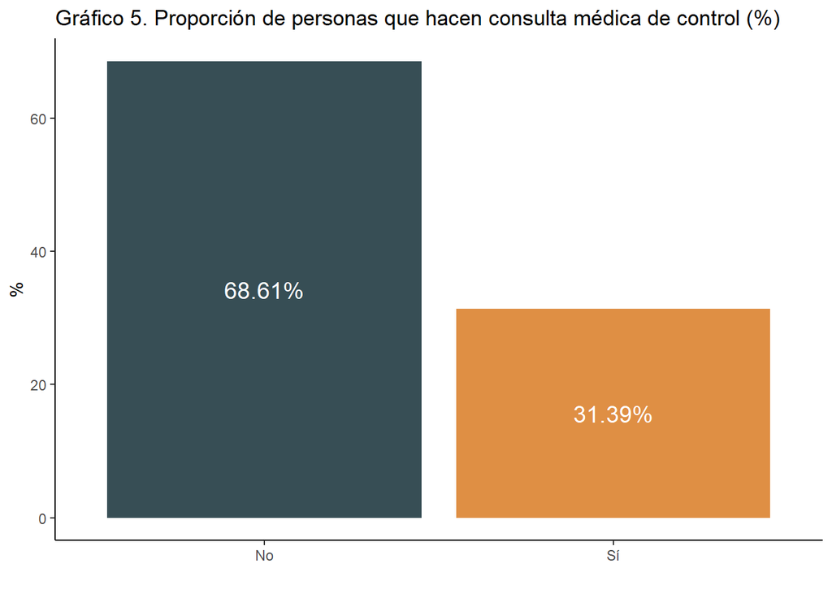

En el *Gráfico 6* se reporta la proporción de personas que tienen problemas de salud crónicos según si estas han tenido que posponer consultas

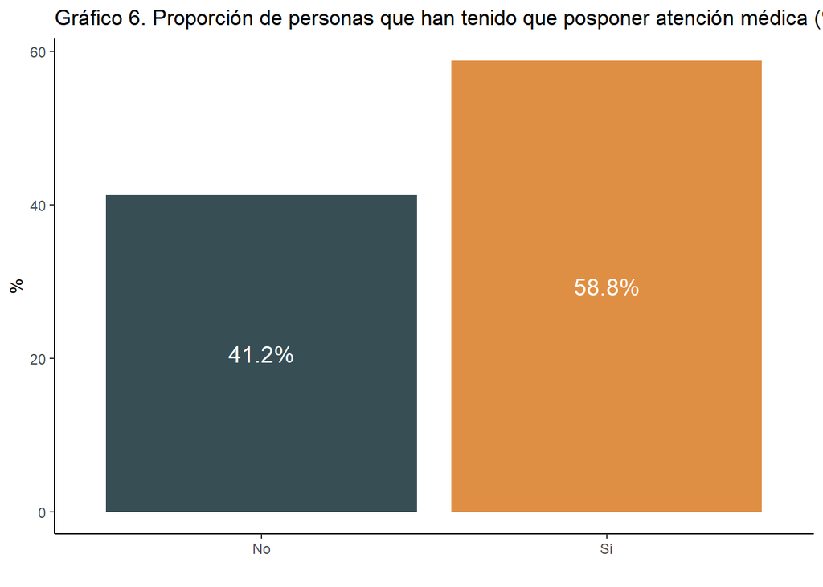

### 3.1.1 Composición sociodemográfica

En la *Tabla 6* se describe las características sociodemográficas de quienes reportan un **problema de salud crónico**, indicando la proporción de quiénes de ellos realizaron o no consultas médicas.

**Tabla 6.** Estadísticos descriptivos para quienes tienen problemas de salud crónicos y si consultan consultas

| Sociodemográfico Variable | Sociodemográfico Subgrupo | Acceso Consultó | Acceso n | Acceso % |
| --- | --- | --- | --- | --- |
| **Edad** |  |  |  |  |
| edad_3cat | 18 a 39 | No | 665 | 70.59 |
|  |  | Sí | 277 | 29.41 |
|  | 40 a 64 | No | 2371 | 69.41 |
|  |  | Sí | 1045 | 30.59 |
|  | 65 y más | No | 1174 | 66.03 |
|  |  | Sí | 604 | 33.97 |
| **Nivel Educacional** |  |  |  |  |
| educ_4cat | Basica o sin estudios | No | 9 | 69.23 |
|  |  | Sí | 4 | 30.77 |
|  | Media | No | 327 | 71.24 |
|  |  | Sí | 132 | 28.76 |
|  | Profesional | No | 3232 | 67.86 |
|  |  | Sí | 1531 | 32.14 |
|  | Tecnica | No | 640 | 71.27 |
|  |  | Sí | 258 | 28.73 |
| **Región** |  |  |  |  |
| region | Antofagasta | No | 52 | 64.20 |
|  |  | Sí | 29 | 35.80 |
|  | Arica y Parinacota | No | 24 | 66.67 |
|  |  | Sí | 12 | 33.33 |
|  | Atacama | No | 25 | 83.33 |
|  |  | Sí | 5 | 16.67 |
|  | Aysén del General Carlos Ibáñez del Campo | No | 12 | 70.59 |
|  |  | Sí | 5 | 29.41 |
|  | Biobío | No | 194 | 69.78 |
|  |  | Sí | 84 | 30.22 |
|  | Coquimbo | No | 96 | 68.57 |
|  |  | Sí | 44 | 31.43 |
|  | La Araucanía | No | 103 | 73.05 |
|  |  | Sí | 38 | 26.95 |
|  | Libertador General Bernardo O’Higgins | No | 88 | 64.71 |
|  |  | Sí | 48 | 35.29 |
|  | Los Lagos | No | 101 | 66.01 |
|  |  | Sí | 52 | 33.99 |
|  | Los Ríos | No | 53 | 66.25 |
|  |  | Sí | 27 | 33.75 |
|  | Magallanes y de la Antártica Chilena | No | 25 | 58.14 |
|  |  | Sí | 18 | 41.86 |
|  | Maule | No | 90 | 76.27 |
|  |  | Sí | 28 | 23.73 |
|  | Metropolitana de Santiago | No | 2816 | 68.05 |
|  |  | Sí | 1322 | 31.95 |
|  | Ñuble | No | 39 | 72.22 |
|  |  | Sí | 15 | 27.78 |
|  | Tarapacá | No | 21 | 63.64 |
|  |  | Sí | 12 | 36.36 |
|  | Valparaíso | No | 469 | 71.49 |
|  |  | Sí | 187 | 28.51 |
| **Sexo** |  |  |  |  |
| sexo | Femenino | No | 2682 | 68.75 |
|  |  | Sí | 1219 | 31.25 |
|  | Masculino | No | 1522 | 68.34 |
|  |  | Sí | 705 | 31.66 |
|  | Otro | No | 6 | 75.00 |
|  |  | Sí | 2 | 25.00 |

El *Gráfico 7 y 8* muestra la distribución de si consultan y posponen según previsión de salud. Podemos notar que quiénes tienen *FONASA* y *Ninguna* son quienes menos acceden a prestaciones de salud.

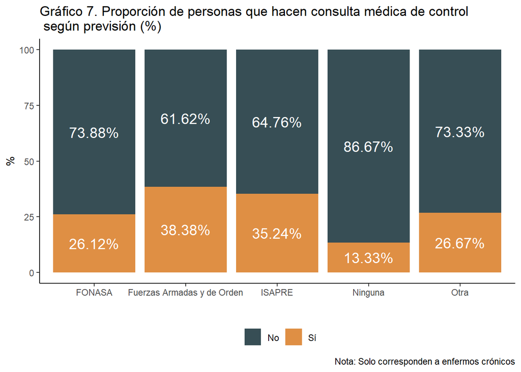

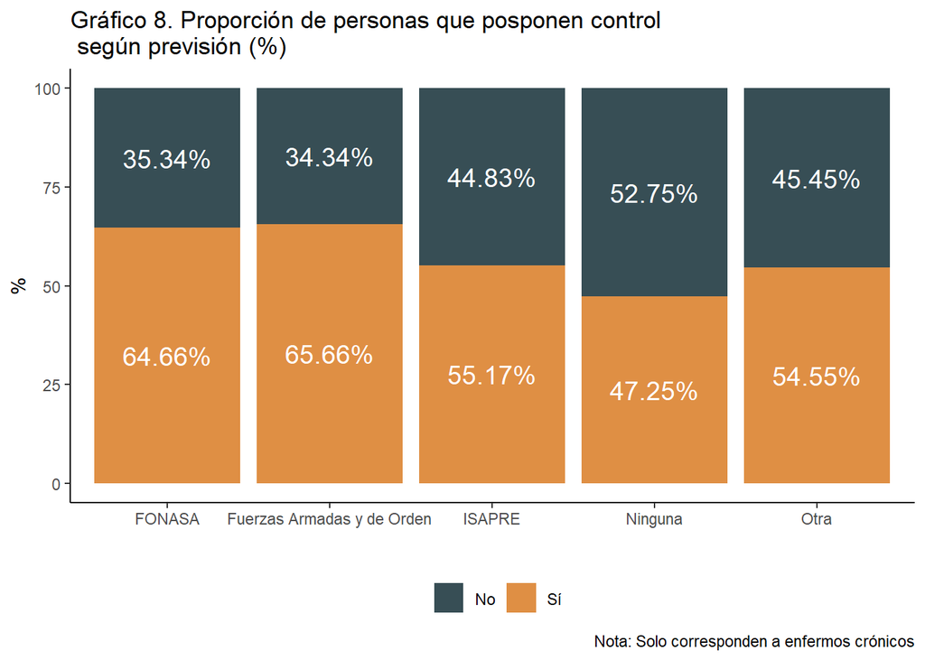

## 3.2 Acceso según división servicio salud

| Servicio de Salud | Consultó | n | % |
| --- | --- | --- | --- |
| Aconcagua | No | 33 | 61.11 |
|  | Sí | 21 | 38.89 |
| Antofagasta | No | 52 | 64.20 |
|  | Sí | 29 | 35.80 |
| Araucania Norte | No | 7 | 100.00 |
| Araucania Sur | No | 86 | 70.49 |
|  | Sí | 36 | 29.51 |
| Arauco | No | 5 | 71.43 |
|  | Sí | 2 | 28.57 |
| Arica | No | 24 | 66.67 |
|  | Sí | 12 | 33.33 |
| Atacama | No | 6 | 75.00 |
|  | Sí | 2 | 25.00 |
| Aysen | No | 1 | 100.00 |
| Biobio | No | 6 | 85.71 |
|  | Sí | 1 | 14.29 |
| Chiloe | No | 17 | 70.83 |
|  | Sí | 7 | 29.17 |
| Concepcion | No | 23 | 79.31 |
|  | Sí | 6 | 20.69 |
| Coquimbo | No | 94 | 68.12 |
|  | Sí | 44 | 31.88 |
| del Maule | No | 69 | 82.14 |
|  | Sí | 15 | 17.86 |
| del Reloncavi | No | 56 | 65.88 |
|  | Sí | 29 | 34.12 |
| Iquique | No | 21 | 63.64 |
|  | Sí | 12 | 36.36 |
| Magallanes | No | 24 | 57.14 |
|  | Sí | 18 | 42.86 |
| Metropolitano Central | No | 276 | 68.49 |
|  | Sí | 127 | 31.51 |
| Metropolitano Norte | No | 167 | 67.89 |
|  | Sí | 79 | 32.11 |
| Metropolitano Occidente | No | 112 | 69.57 |
|  | Sí | 49 | 30.43 |
| Metropolitano Oriente | No | 945 | 65.76 |
|  | Sí | 492 | 34.24 |
| Metropolitano Sur | No | 231 | 71.52 |
|  | Sí | 92 | 28.48 |
| Metropolitano Suroriente | No | 329 | 70.60 |
|  | Sí | 137 | 29.40 |
| Nuble | No | 11 | 73.33 |
|  | Sí | 4 | 26.67 |
| OHiggins | No | 70 | 64.22 |
|  | Sí | 39 | 35.78 |
| Osorno | No | 24 | 63.16 |
|  | Sí | 14 | 36.84 |
| Talcahuano | No | 22 | 68.75 |
|  | Sí | 10 | 31.25 |
| Valdivia | No | 53 | 66.25 |
|  | Sí | 27 | 33.75 |
| Valparaiso San Antonio | No | 52 | 70.27 |
|  | Sí | 22 | 29.73 |
| Vina del Mar Quillota | No | 71 | 75.53 |
|  | Sí | 23 | 24.47 |

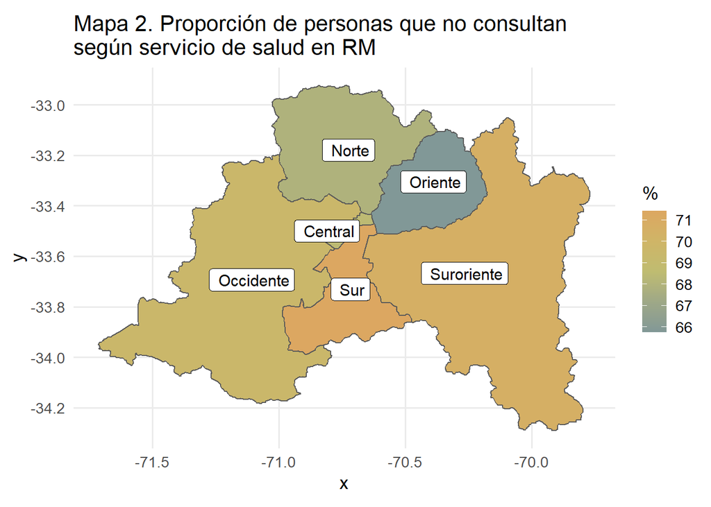

## 3.3 Razones para posponer prestaciones

**Tabla 7.** Proporción de personas que reporta cada razón para posponer

| Razón | n | % |
| --- | --- | --- |
| Servicio de salud cancela | 1111 | 30.96 |
| Costo económico | 123 | 3.43 |
| Cuidados | 114 | 3.18 |
| No importa | 137 | 3.82 |
| No sabía | 85 | 2.37 |
| Otra | 413 | 11.51 |
| Sistema lleno | 533 | 14.85 |
| Miedo al contagio | 2251 | 62.72 |
| Transporte | 113 | 3.15 |

## 3.4 Análisis por tipo de enfermedad crónica

**Tabla 8.** Proporción de personas que reporta consultar según tipo de enfermedad

| Enfermedad | Consulta | n | % |
| --- | --- | --- | --- |
| x1_prx_cardio | No | 423 | 66.30 |
|  | Si | 215 | 33.70 |
| x1_prx_diabetes | No | 583 | 63.58 |
|  | Si | 334 | 36.42 |
| x1_prx_fuma | No | 732 | 71.21 |
|  | Si | 296 | 28.79 |
| x1_prx_hipertension | No | 2148 | 67.82 |
|  | Si | 1019 | 32.18 |
| x1_prx_inmuno | No | 353 | 56.94 |
|  | Si | 267 | 43.06 |
| x1_prx_oncologico | No | 141 | 42.86 |
|  | Si | 188 | 57.14 |
| x1_prx_renal | No | 4 | 33.33 |
|  | Si | 8 | 66.67 |
| x1_prx_respiratoria | No | 874 | 69.53 |
|  | Si | 383 | 30.47 |
| x1_prx_sobrepeso | No | 152 | 71.03 |
|  | Si | 62 | 28.97 |

**Tabla 9.** Proporción de personas que posponen según enfermedad crónica

| Enfermedad | Pospone | n | % |
| --- | --- | --- | --- |
| x1_prx_cardio | No | 220 | 34.87 |
|  | Si | 411 | 65.13 |
| x1_prx_diabetes | No | 217 | 23.85 |
|  | Si | 693 | 76.15 |
| x1_prx_fuma | No | 429 | 41.89 |
|  | Si | 595 | 58.11 |
| x1_prx_hipertension | No | 1164 | 37.03 |
|  | Si | 1979 | 62.97 |
| x1_prx_inmuno | No | 160 | 25.72 |
|  | Si | 462 | 74.28 |
| x1_prx_oncologico | No | 99 | 30.28 |
|  | Si | 228 | 69.72 |
| x1_prx_renal | No | 8 | 66.67 |
|  | Si | 4 | 33.33 |
| x1_prx_respiratoria | No | 463 | 36.98 |
|  | Si | 789 | 63.02 |
| x1_prx_sobrepeso | No | 95 | 45.24 |
|  | Si | 115 | 54.76 |

**Tabla 10.** Proporción de personas que reporta cada razón para posponer según tipo enfermedad

| Enfermedad | Razón | n | % |
| --- | --- | --- | --- |
| x1_prx_cardio | Servicio de salud cancela | 156 | 37.96 |
|  | Costo económico | 24 | 5.84 |
|  | Cuidados | 8 | 1.95 |
|  | No importa | 11 | 2.68 |
|  | No sabía | 11 | 2.68 |
|  | Otra | 53 | 12.90 |
|  | Sistema lleno | 63 | 15.33 |
|  | Miedo al contagio | 241 | 58.64 |
|  | Transporte | 18 | 4.38 |
| x1_prx_diabetes | Servicio de salud cancela | 281 | 40.84 |
|  | Costo económico | 22 | 3.20 |
|  | Cuidados | 12 | 1.74 |
|  | No importa | 17 | 2.47 |
|  | No sabía | 13 | 1.89 |
|  | Otra | 77 | 11.19 |
|  | Sistema lleno | 93 | 13.52 |
|  | Miedo al contagio | 387 | 56.25 |
|  | Transporte | 20 | 2.91 |
| x1_prx_fuma | Servicio de salud cancela | 191 | 32.10 |
|  | Costo económico | 21 | 3.53 |
|  | Cuidados | 18 | 3.03 |
|  | No importa | 12 | 2.02 |
|  | No sabía | 11 | 1.85 |
|  | Otra | 64 | 10.76 |
|  | Sistema lleno | 100 | 16.81 |
|  | Miedo al contagio | 389 | 65.38 |
|  | Transporte | 25 | 4.20 |
| x1_prx_hipertension | Servicio de salud cancela | 647 | 32.71 |
|  | Costo económico | 54 | 2.73 |
|  | Cuidados | 52 | 2.63 |
|  | No importa | 80 | 4.04 |
|  | No sabía | 43 | 2.17 |
|  | Otra | 222 | 11.22 |
|  | Sistema lleno | 302 | 15.27 |
|  | Miedo al contagio | 1234 | 62.39 |
|  | Transporte | 57 | 2.88 |
| x1_prx_inmuno | Servicio de salud cancela | 146 | 31.67 |
|  | Costo económico | 20 | 4.34 |
|  | Cuidados | 14 | 3.04 |
|  | No importa | 14 | 3.04 |
|  | No sabía | 13 | 2.82 |
|  | Otra | 72 | 15.62 |
|  | Sistema lleno | 67 | 14.53 |
|  | Miedo al contagio | 274 | 59.44 |
|  | Transporte | 19 | 4.12 |
| x1_prx_oncologico | Servicio de salud cancela | 72 | 31.58 |
|  | Costo económico | 3 | 1.32 |
|  | Cuidados | 4 | 1.75 |
|  | No importa | 3 | 1.32 |
|  | No sabía | 5 | 2.19 |
|  | Otra | 35 | 15.35 |
|  | Sistema lleno | 30 | 13.16 |
|  | Miedo al contagio | 145 | 63.60 |
|  | Transporte | 14 | 6.14 |
| x1_prx_renal | Servicio de salud cancela | 3 | 75.00 |
|  | Costo económico | 1 | 25.00 |
|  | Otra | 1 | 25.00 |
|  | Sistema lleno | 2 | 50.00 |
|  | Miedo al contagio | 1 | 25.00 |
| x1_prx_respiratoria | Servicio de salud cancela | 220 | 27.92 |
|  | Costo económico | 25 | 3.17 |
|  | Cuidados | 33 | 4.19 |
|  | No importa | 29 | 3.68 |
|  | No sabía | 24 | 3.05 |
|  | Otra | 98 | 12.44 |
|  | Sistema lleno | 120 | 15.23 |
|  | Miedo al contagio | 516 | 65.48 |
|  | Transporte | 18 | 2.28 |
| x1_prx_sobrepeso | Servicio de salud cancela | 35 | 30.43 |
|  | Costo económico | 2 | 1.74 |
|  | Cuidados | 3 | 2.61 |
|  | No importa | 7 | 6.09 |
|  | No sabía | 5 | 4.35 |
|  | Otra | 7 | 6.09 |
|  | Sistema lleno | 19 | 16.52 |
|  | Miedo al contagio | 75 | 65.22 |
|  | Transporte | 5 | 4.35 |

[figure not shown]

[figure not shown]

# 4 Razones para posponer de ambos grupos

**Tabla 12.** Proporción de personas que reporta cada razón para posponer

| Razón para posponer consulta | Nuevo problema salud n | Nuevo problema salud % | Enfermos crónicos n | Enfermos crónicos % |
| --- | --- | --- | --- | --- |
| Costo económico | 939 | 5.96 | 123 | 3.43 |
| Deber cuidar de otros | 608 | 3.86 | 114 | 3.18 |
| El sistema está lleno | 2010 | 12.75 | 533 | 14.85 |
| Espera empeorar | 965 | 6.12 |  |  |
| Los síntomas son leves | 1486 | 9.43 |  |  |
| Miedo al contagio | 9013 | 57.18 | 2251 | 62.72 |
| No considera importante | 1510 | 9.58 | 137 | 3.82 |
| No sabía donde ir | 285 | 1.81 | 85 | 2.37 |
| No tener transporte | 375 | 2.38 | 113 | 3.15 |
| Otra razón | 2689 | 17.06 | 413 | 11.51 |
| Por falta de tiempo | 500 | 3.17 |  |  |
| Servicio de salud cancela | 2547 | 16.16 | 1111 | 30.96 |

# 5 Comparación con CASEN 2017

## 5.1 Tasa de atención médica ante problema de salud en los últimos 3 meses

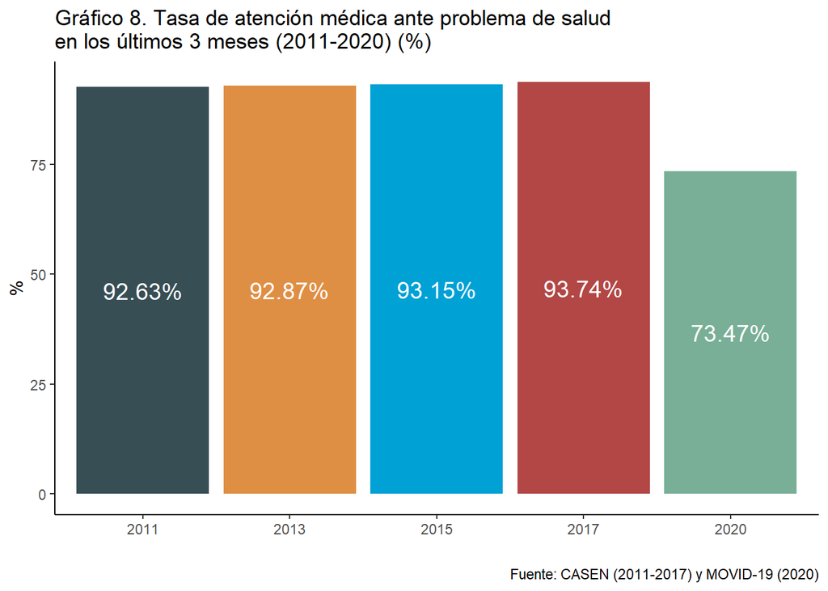

[figure not shown]